# Prediction Assignment Accelerometer

Earl Bingham

August 22, 2016

## Synopsis

The goal of this assignment was to quantify how well the users of personal activity devices are doing. The predictions used the Weight Lifting Exercise Dataset provided by the Pontifical Catholic University of Rio de Janeiro. The analysis started from the raw data file, a comma seperated value file. What follows is the code used for the analysis, and comments regarding the results and assumptions that can be made.

## Weight Lifting Exercises Dataset

The training dataset for this assignment: https://d396qusza40orc.cloudfront.net/predmachlearn/pml-training.csv

The test dataset for this assigment: https://d396qusza40orc.cloudfront.net/predmachlearn/pml-testing.csv The test dataset contains 20 rows Both datasets need to be in the local working directory for this R markdown document to recreate the results. The data for this project is kindly provided by:

Velloso, E.; Bulling, A.; Gellersen, H.; Ugulino, W.; Fuks, H.: Qualitative Activity Recognition of Weight Lifting Exercises. Proceedings of 4th International Conference in Cooperation with SIGCHI (Augmented Human ’13). Stuttgart, Germany: ACM SIGCHI, 2013 (http://groupware.les.inf.puc-rio.br/work.jsf?p1=11201).

The Weight Lifting Exercises dataset is used to investigate how well an activity is being performed. Six participants were performing one set of 10 repetitions of the Unilateral Dumbbell Biceps Curl in five different fashions:

Class A - Exactly according to the specification Class B - Throwing the elbows to the front Class C - Lifting the dumbbell only halfway Class D - Lowering the dumbbell only halfway Class E - Throwing the hips to the front Class A corresponds to the specified execution of the exercise, while the other 4 classes correspond to common mistakes.

## Data Processing

Load the data

```r
install.packages('caret', dependencies = TRUE, repos="http://cran.rstudio.com/")
install.packages('e1071', dependencies=TRUE, repos="http://cran.rstudio.com/")
options(digits = 7)
library(caret);library(randomForest)
training <- read.csv("pml-training.csv")
testing <- read.csv("pml-testing.csv")
```

Group specific the features defined into 52 predictors in our 160 variable test and training datasets.

```r
predGroups <- c(grep("^accel", names(training)), grep("^gyros", names(training)), grep("^magnet", names(training)), grep("^roll", names(training)), grep("^pitch", names(training)), grep("^yaw", names(training)), grep("^total", names(training)))
trainPredGrps <- training[, c(predGroups, 160)]
testPredGrps <- testing[, c(predGroups, 160)]
```

Removes predictors that have one unique value across samples, and remove predictors that have both few unique values relative to the number of samples.

```r
nearZeroVar(trainPredGrps[, -53], saveMetric = TRUE)
```

```
##                      freqRatio percentUnique zeroVar   nzv
## accel_belt_x          1.055412     0.8357966   FALSE FALSE
## accel_belt_y          1.113725     0.7287738   FALSE FALSE
## accel_belt_z          1.078767     1.5237998   FALSE FALSE
## accel_arm_x           1.017341     3.9598410   FALSE FALSE
## accel_arm_y           1.140187     2.7367241   FALSE FALSE
## accel_arm_z           1.128000     4.0362858   FALSE FALSE
## accel_dumbbell_x      1.018018     2.1659362   FALSE FALSE
## accel_dumbbell_y      1.053061     2.3748853   FALSE FALSE
## accel_dumbbell_z      1.133333     2.0894914   FALSE FALSE
## accel_forearm_x       1.126437     4.0464784   FALSE FALSE
## accel_forearm_y       1.059406     5.1116094   FALSE FALSE
## accel_forearm_z       1.006250     2.9558659   FALSE FALSE
## gyros_belt_x          1.058651     0.7134849   FALSE FALSE
## gyros_belt_y          1.144000     0.3516461   FALSE FALSE
## gyros_belt_z          1.066214     0.8612782   FALSE FALSE
## gyros_arm_x           1.015504     3.2769341   FALSE FALSE
## gyros_arm_y           1.454369     1.9162165   FALSE FALSE
## gyros_arm_z           1.110687     1.2638875   FALSE FALSE
## gyros_dumbbell_x      1.003268     1.2282132   FALSE FALSE
## gyros_dumbbell_y      1.264957     1.4167771   FALSE FALSE
## gyros_dumbbell_z      1.060100     1.0498420   FALSE FALSE
## gyros_forearm_x       1.059273     1.5187035   FALSE FALSE
## gyros_forearm_y       1.036554     3.7763735   FALSE FALSE
## gyros_forearm_z       1.122917     1.5645704   FALSE FALSE
## magnet_belt_x         1.090141     1.6664968   FALSE FALSE
## magnet_belt_y         1.099688     1.5187035   FALSE FALSE
## magnet_belt_z         1.006369     2.3290184   FALSE FALSE
## magnet_arm_x          1.000000     6.8239731   FALSE FALSE
## magnet_arm_y          1.056818     4.4439914   FALSE FALSE
## magnet_arm_z          1.036364     6.4468454   FALSE FALSE
## magnet_dumbbell_x     1.098266     5.7486495   FALSE FALSE
## magnet_dumbbell_y     1.197740     4.3012945   FALSE FALSE
## magnet_dumbbell_z     1.020833     3.4451126   FALSE FALSE
## magnet_forearm_x      1.012346     7.7667924   FALSE FALSE
## magnet_forearm_y      1.246914     9.5403119   FALSE FALSE
## magnet_forearm_z      1.000000     8.5771073   FALSE FALSE
## roll_belt             1.101904     6.7781062   FALSE FALSE
## roll_arm             52.338462    13.5256345   FALSE FALSE
## roll_dumbbell         1.022388    84.2065029   FALSE FALSE
## roll_forearm         11.589286    11.0895933   FALSE FALSE
## pitch_belt            1.036082     9.3772296   FALSE FALSE
## pitch_arm            87.256410    15.7323412   FALSE FALSE
## pitch_dumbbell        2.277372    81.7449801   FALSE FALSE
## pitch_forearm        65.983051    14.8557741   FALSE FALSE
## yaw_belt              1.058480     9.9734991   FALSE FALSE
## yaw_arm              33.029126    14.6570176   FALSE FALSE
## yaw_dumbbell          1.132231    83.4828254   FALSE FALSE
## yaw_forearm          15.322835    10.1467740   FALSE FALSE
## total_accel_belt      1.063160     0.1477933   FALSE FALSE
## total_accel_arm       1.024526     0.3363572   FALSE FALSE
## total_accel_dumbbell  1.072634     0.2191418   FALSE FALSE
## total_accel_forearm   1.128928     0.3567424   FALSE FALSE
```

The plot below shows that the final group ‘E’ had a number of varing results due to how the different test subjects would throw their hips. It represents a Report of how I built my model.

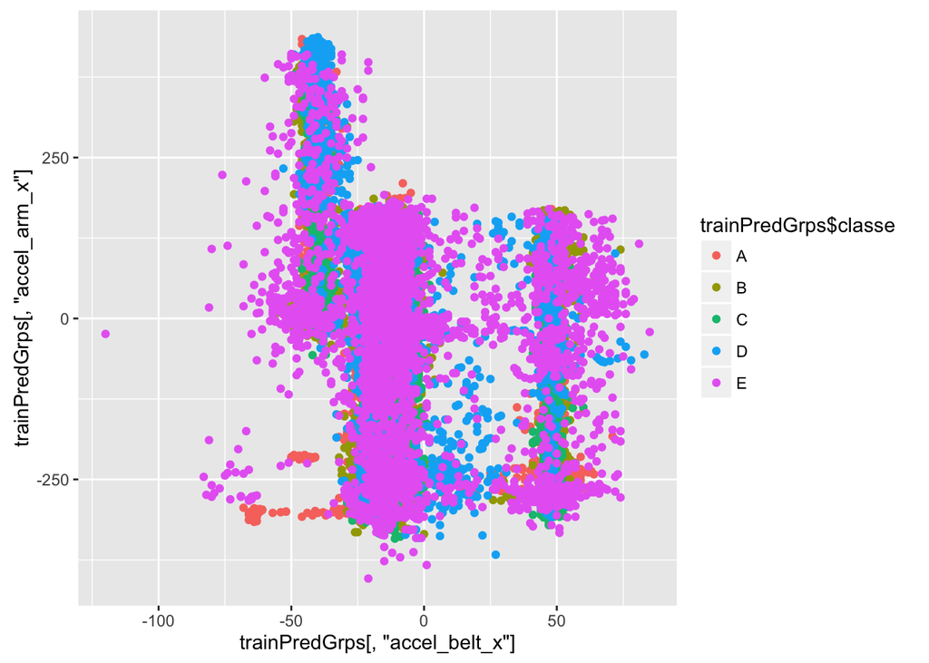

```r
qplot(x = trainPredGrps[, "accel_belt_x"], y = trainPredGrps[, "accel_arm_x"],
      color = trainPredGrps$classe)
```

## Training Dataset and Cross-Validation

In order to evaluate our prediction algorithm cross-validation is used. The training set is split into a cross-validation training set cvTrain and test set cvTest. So we can train our model on the cvTrain dataset and test the accuracy of our prediction on the cvTest dataset in order to evaluate the influence of different training methods, predictor selections and predictor preprocessing methods.

```r
set.seed(125)
inTrain <- createDataPartition(y = trainPredGrps$classe, p = 0.75, list = FALSE)
cvTrain <- trainPredGrps[inTrain, ]
cvTest <- trainPredGrps[-inTrain, ]

fitCtrl <- trainControl(method = "repeatedcv", number = 10, repeats = 10)
```

```r
set.seed(125)
modFit <- train(classe ~ ., data = cvTrain, method = "qda", preProcess = c("center", "scale"), trControl = fitCtrl)

ptrain <- predict(modFit, newdata = cvTrain)
equalPredTrain <- (ptrain == cvTrain$classe)
print(sum(equalPredTrain)/length(equalPredTrain))
```

```
## [1] 0.9025003
```

```r
confusionMatrix(data = ptrain, reference = cvTrain$classe)
```

```
## Confusion Matrix and Statistics
##
##           Reference
## Prediction    A    B    C    D    E
##          A 3884  132    0    3    0
##          B  154 2425  104    7   80
##          C   77  265 2447  314  104
##          D   62    9    9 2062   57
##          E    8   17    7   26 2465
##
## Overall Statistics
##
##                Accuracy : 0.9025
##                  95% CI : (0.8976, 0.9072)
##     No Information Rate : 0.2843
##     P-Value [Acc > NIR] : < 2.2e-16
##
##                   Kappa : 0.8769
##  Mcnemar's Test P-Value : < 2.2e-16
##
## Statistics by Class:
##
##                      Class: A Class: B Class: C Class: D Class: E
## Sensitivity            0.9281   0.8515   0.9533   0.8549   0.9109
## Specificity            0.9872   0.9709   0.9375   0.9889   0.9952
## Pos Pred Value         0.9664   0.8755   0.7630   0.9377   0.9770
## Neg Pred Value         0.9719   0.9646   0.9896   0.9720   0.9802
## Prevalence             0.2843   0.1935   0.1744   0.1639   0.1839
## Detection Rate         0.2639   0.1648   0.1663   0.1401   0.1675
## Detection Prevalence   0.2731   0.1882   0.2179   0.1494   0.1714
## Balanced Accuracy      0.9576   0.9112   0.9454   0.9219   0.9531
```

The cross validation test set (cvTest) shows accuracy and estimates the out-of-sample error rate of the prediction model, giving 89%.

```r
ptest <- predict(modFit, newdata = cvTest)
equalPredTest <- (ptest == cvTest$classe)
print(sum(equalPredTest)/length(equalPredTest))
```

```
## [1] 0.8890701
```

```r
confusionMatrix(data = ptest, reference = cvTest$classe)
```

```
## Confusion Matrix and Statistics
##
##           Reference
## Prediction    A    B    C    D    E
##          A 1269   53    2    1    0
##          B   72  793   45    4   25
##          C   29   88  804  103   41
##          D   21    3    3  687   28
##          E    4   12    1    9  807
##
## Overall Statistics
##
##                Accuracy : 0.8891
##                  95% CI : (0.8799, 0.8977)
##     No Information Rate : 0.2845
##     P-Value [Acc > NIR] : < 2.2e-16
##
##                   Kappa : 0.86
##  Mcnemar's Test P-Value : < 2.2e-16
##
## Statistics by Class:
##
##                      Class: A Class: B Class: C Class: D Class: E
## Sensitivity            0.9097   0.8356   0.9404   0.8545   0.8957
## Specificity            0.9840   0.9631   0.9355   0.9866   0.9935
## Pos Pred Value         0.9577   0.8445   0.7549   0.9259   0.9688
## Neg Pred Value         0.9648   0.9607   0.9867   0.9719   0.9769
## Prevalence             0.2845   0.1935   0.1743   0.1639   0.1837
## Detection Rate         0.2588   0.1617   0.1639   0.1401   0.1646
## Detection Prevalence   0.2702   0.1915   0.2172   0.1513   0.1699
## Balanced Accuracy      0.9469   0.8994   0.9379   0.9205   0.9446
```

```r
trainFit <-randomForest(classe ~., data = cvTrain, importance = TRUE)
print(trainFit)
```

```
##
## Call:
##  randomForest(formula = classe ~ ., data = cvTrain, importance = TRUE)
##                Type of random forest: classification
##                      Number of trees: 500
## No. of variables tried at each split: 7
##
##         OOB estimate of  error rate: 0.48%
## Confusion matrix:
##      A    B    C    D    E  class.error
## A 4181    3    0    0    1 0.0009557945
## B   13 2834    1    0    0 0.0049157303
## C    0   18 2548    1    0 0.0074016362
## D    0    0   24 2387    1 0.0103648425
## E    0    0    2    6 2698 0.0029563932
```

What follows is the prediction model to predict 20 different test cases from the 160 variables.

```r
testPrediction <- predict(modFit, newdata = testing)
print(rbind(testing[1:20, 160], as.character(testPrediction)))
```

```
##      [,1] [,2] [,3] [,4] [,5] [,6] [,7] [,8] [,9] [,10] [,11] [,12] [,13]
## [1,] "1"  "2"  "3"  "4"  "5"  "6"  "7"  "8"  "9"  "10"  "11"  "12"  "13"
## [2,] "A"  "A"  "B"  "A"  "A"  "E"  "D"  "B"  "A"  "A"   "B"   "C"   "B"
##      [,14] [,15] [,16] [,17] [,18] [,19] [,20]
## [1,] "14"  "15"  "16"  "17"  "18"  "19"  "20"
## [2,] "A"   "E"   "E"   "A"   "B"   "B"   "B"
```